# Guía 2, ICO8305

Ricardo Mayer

2019-09-27

# 1 Segunda guía de práctica

Continuamos avanzando en la lista de cosas que deben saber. En esta guía veremos listas, indexación, manipulación de data frames y traer datos desde excel y un par de cosas más. Es el final de la lista de la guía 1 con unos cuantos agregados pensados especialemnte para este curso

13. Sabes como crear una lista?
14. Sabes como seleccionar partes de un vector? de un data.frame? de una lista?
15. Sabes como manipular un data.frame o un tibble?
16. Puedes crear un diagrama de dispersión, un diagrama de caja usando ggplot2?
17. Sabes cómo importar una hoja de Excel en R?
18. Has escrito un `for` loop?
19. Has escrito una función?

## 1.1 Crear listas

Las listas son un tipo de objecto muy versátil, porque dentro de una misma lista puedes incluir números, texto, data frames, tibbles, otras listas etc. Hay muchas funciones que retornan una gran lista como resultado y a menudo uno debe escoger qué elemento de la lista es el que nos interesa.

Veamos cómo crear manualmente una lista:

```r
# de la guía 1, pero  note el stringsAsFactors = FALSE
notas_curso_df <- read.csv2("notas_curso.csv", stringsAsFactors = FALSE)

# también de la guía 1
library(readxl) # instaló el package "readxl", cierto?
notas_curso_tbl <- read_excel("notas_curso.xlsx")

un_vector <- c(2,1,6,-8,9,-2)

otro_vector <- rnorm(50, mean = 0.5, sd = 2)
# Dado que rnorm genera números (pseudo)aleatorios, *no* van a ser los mismos
# que usted obtendrá (a menos que hagamos algo extra, pero
# eso lo discutiremos más adelante)

# a,b, un_df y un_tbl son los nombres que le daremos a los elementos
# de esta lista. Podríamos no usar nombres.
lista_ejemplo <- list(a = "Hola", b = 4,
                      un_v = un_vector, otro_v = otro_vector,
                      un_df = notas_curso_df,
                      un_tibble = notas_curso_tbl)

lista_ejemplo
```

```
## $a
## [1] "Hola"
##
## $b
## [1] 4
##
## $un_v
## [1]  2  1  6 -8  9 -2
##
## $otro_v
##  [1] -1.304946415  0.062797444 -0.242506906  2.955945241  1.291780272
##  [6]  4.158277165  1.482598846  0.706498888  0.689295699  0.549659349
## [11]  1.560361897 -0.287730480  0.471319014  3.005874109 -5.686604992
## [16]  0.721416357  2.594393993  0.911929897 -3.565701842  0.616101613
## [21] -0.132204245  1.466297341  4.376510026  0.308443108  2.044729210
## [26] -1.305810896  2.735017215  1.349027034 -0.761289756  0.742330816
## [31]  1.688300947  0.112822846  0.966942035 -1.199356373 -1.204232053
## [36]  3.638692261  0.936632301 -0.159054610 -2.056311293 -0.004862222
## [41]  1.763014742 -1.473100438  1.203748245 -1.110772071  0.723449607
## [46]  0.329212793 -1.736020194  3.407412752  1.364009595 -0.394199088
##
## $un_df
##   nombre solemne controles examen final
## 1  pedro     3.5       5.0    3.0   3.8
## 2   juan     4.0       3.0    4.0   3.7
## 3  diego     5.0       6.0    4.8   5.2
## 4  frida     6.0       6.5    5.5   6.0
## 5 simone     5.5       7.0    6.0   6.2
## 6 judith     7.0       6.0    6.0   6.3
##
## $un_tibble
## # A tibble: 6 x 5
##   nombre solemne controles examen final
##   <chr>    <dbl>     <dbl>  <dbl> <dbl>
## 1 pedro      3.5       5      3     3.8
## 2 juan       4         3      4     3.7
## 3 diego      5         6      4.8   5.2
## 4 frida      6         6.5    5.5   6
## 5 simone     5.5       7      6     6.2
## 6 judith     7         6      6     6.3
```

```r
class(lista_ejemplo)
```

```
## [1] "list"
```

## 1.2 Seleccionar partes de una lista, vector o data frame

La manera más general de referirse a una parte de un objeto es usar `[]` o `[[]]`. Al comienzo, es completamente esperable equivacarse en cual de los dos usar, aunque hayamos leído las instrucciones recientemente … pero para eso es la consola!! Para experimentar y *encontrar* la forma correcta de hacer las cosas, probando varias posibilidades y viendo los resultados.

Veamos algunos ejemplos (como siempre, copie estos ejemplos en su sesión para probarlos y explorarlos por su cuenta)

```r
un_vector
```

```
## [1]  2  1  6 -8  9 -2
```

```r
un_vector[1:3]
```

```
## [1] 2 1 6
```

```r
un_vector[c(1, 4, 6)]
```

```
## [1]  2 -8 -2
```

```r
# identico resultado:
un_vector[c(TRUE, FALSE, FALSE, TRUE, FALSE, TRUE)]
```

```
## [1]  2 -8 -2
```

```r
# qué ocurre aquí?:
un_vector[un_vector < 0]
```

```
## [1] -8 -2
```

```r
# df, usando números
# recuerde: [filas, columnas]
notas_curso_df[1,1]
```

```
## [1] "pedro"
```

```r
notas_curso_df[1, ]
```

```
##   nombre solemne controles examen final
## 1  pedro     3.5         5      3   3.8
```

```r
notas_curso_df[, 2]
```

```
## [1] 3.5 4.0 5.0 6.0 5.5 7.0
```

```r
notas_curso_df[c(1,3), 1:3]
```

```
##   nombre solemne controles
## 1  pedro     3.5         5
## 3  diego     5.0         6
```

```r
# para seleccionar columnas usualmente podemos usar
# sus nombres --sin comillas-- y el signo peso
notas_curso_df$nombre
```

```
## [1] "pedro"  "juan"   "diego"  "frida"  "simone" "judith"
```

```r
notas_curso_df$solemne
```

```
## [1] 3.5 4.0 5.0 6.0 5.5 7.0
```

```r
# df, usando nombres o valores
# recuerde usar comillas para los nombres dentro de los
notas_curso_df[1, "nombre"]
```

```
## [1] "pedro"
```

```r
notas_curso_df[notas_curso_df$nombre == "pedro" , ] #que ocurrió aquí?
```

```
##   nombre solemne controles examen final
## 1  pedro     3.5         5      3   3.8
```

```r
notas_curso_df[, "solemne"]
```

```
## [1] 3.5 4.0 5.0 6.0 5.5 7.0
```

```r
notas_curso_df[c(1,3), c("nombre", "solemne", "controles")]
```

```
##   nombre solemne controles
## 1  pedro     3.5         5
## 3  diego     5.0         6
```

```r
# listas
# en el caso de las listas es mucho más usual seleccionar *un* elemento
# de la lista, que varios a la vez
lista_ejemplo[[1]]
```

```
## [1] "Hola"
```

```r
lista_ejemplo[[2]]
```

```
## [1] 4
```

```r
lista_ejemplo[[3]]
```

```
## [1]  2  1  6 -8  9 -2
```

```r
lista_ejemplo[["a"]]
```

```
## [1] "Hola"
```

```r
lista_ejemplo[["b"]]
```

```
## [1] 4
```

```r
lista_ejemplo[["un_v"]]
```

```
## [1]  2  1  6 -8  9 -2
```

```r
# el signo peso también funciona, pero para programar es más fácil usar [[]]
lista_ejemplo$a
```

```
## [1] "Hola"
```

```r
lista_ejemplo$otro_v
```

```
##  [1] -1.304946415  0.062797444 -0.242506906  2.955945241  1.291780272
##  [6]  4.158277165  1.482598846  0.706498888  0.689295699  0.549659349
## [11]  1.560361897 -0.287730480  0.471319014  3.005874109 -5.686604992
## [16]  0.721416357  2.594393993  0.911929897 -3.565701842  0.616101613
## [21] -0.132204245  1.466297341  4.376510026  0.308443108  2.044729210
## [26] -1.305810896  2.735017215  1.349027034 -0.761289756  0.742330816
## [31]  1.688300947  0.112822846  0.966942035 -1.199356373 -1.204232053
## [36]  3.638692261  0.936632301 -0.159054610 -2.056311293 -0.004862222
## [41]  1.763014742 -1.473100438  1.203748245 -1.110772071  0.723449607
## [46]  0.329212793 -1.736020194  3.407412752  1.364009595 -0.394199088
```

## 1.3 Sabes como manipular un data.frame o un tibble?

Este es un tópico muy largo, pero nos vamos a concentrar en tres comandos que nos entrega el paquete dplyr: filter, select y summarize. Los comandos funcionan de la misma manera un data frame tradiconal o un tibble (data frame más moderno)

```r
library(dplyr)
select(notas_curso_df, c("nombre", "examen"))
```

```
##   nombre examen
## 1  pedro    3.0
## 2   juan    4.0
## 3  diego    4.8
## 4  frida    5.5
## 5 simone    6.0
## 6 judith    6.0
```

```r
filter(notas_curso_df, examen > 5)
```

```
##   nombre solemne controles examen final
## 1  frida     6.0       6.5    5.5   6.0
## 2 simone     5.5       7.0    6.0   6.2
## 3 judith     7.0       6.0    6.0   6.3
```

```r
select(filter(notas_curso_df, examen > 5), c("nombre", "examen"))
```

```
##   nombre examen
## 1  frida    5.5
## 2 simone    6.0
## 3 judith    6.0
```

```r
# las pipas %>% hacen más legibles algunos programas
# todo se lee de izquierda a derecha
notas_curso_df %>% select(c("nombre", "examen"))
```

```
##   nombre examen
## 1  pedro    3.0
## 2   juan    4.0
## 3  diego    4.8
## 4  frida    5.5
## 5 simone    6.0
## 6 judith    6.0
```

```r
notas_curso_df %>%  filter(examen > 5)
```

```
##   nombre solemne controles examen final
## 1  frida     6.0       6.5    5.5   6.0
## 2 simone     5.5       7.0    6.0   6.2
## 3 judith     7.0       6.0    6.0   6.3
```

```r
notas_curso_df %>%
  filter(examen > 5) %>%
  select(c("nombre", "examen"))
```

```
##   nombre examen
## 1  frida    5.5
## 2 simone    6.0
## 3 judith    6.0
```

```r
notas_curso_df %>%
  summarize(n_estudiantes = n(),
            media_final = mean(final),
            desv_est_final = sd(final))
```

```
##   n_estudiantes media_final desv_est_final
## 1             6         5.2       1.188276
```

## 1.4 Puedes crear un diagrama de dispersión, un diagrama de caja usando ggplot2?

Es muy fácil, sólo necesitas que la información esté un data frame o en un tibble y usar las funciones geom_point y geom_box

```r
library(ggplot2)
library(datos)

diamantes
```

```
## # A tibble: 53,940 x 10
##    precio quilate corte  color claridad profundidad tabla     x     y     z
##     <int>   <dbl> <ord>  <ord> <ord>          <dbl> <dbl> <dbl> <dbl> <dbl>
##  1    326   0.23  Ideal  E     SI2             61.5    55  3.95  3.98  2.43
##  2    326   0.21  Premi~ E     SI1             59.8    61  3.89  3.84  2.31
##  3    327   0.23  Bueno  E     VS1             56.9    65  4.05  4.07  2.31
##  4    334   0.290 Premi~ I     VS2             62.4    58  4.2   4.23  2.63
##  5    335   0.31  Bueno  J     SI2             63.3    58  4.34  4.35  2.75
##  6    336   0.24  Muy b~ J     VVS2            62.8    57  3.94  3.96  2.48
##  7    336   0.24  Muy b~ I     VVS1            62.3    57  3.95  3.98  2.47
##  8    337   0.26  Muy b~ H     SI1             61.9    55  4.07  4.11  2.53
##  9    337   0.22  Regul~ E     VS2             65.1    61  3.87  3.78  2.49
## 10    338   0.23  Muy b~ H     VS1             59.4    61  4     4.05  2.39
## # ... with 53,930 more rows
```

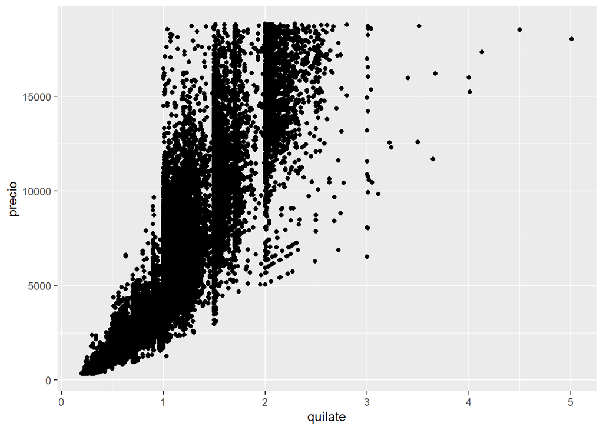

```r
ggplot(data = diamantes) +
  geom_point(aes(x = quilate, y = precio))
```

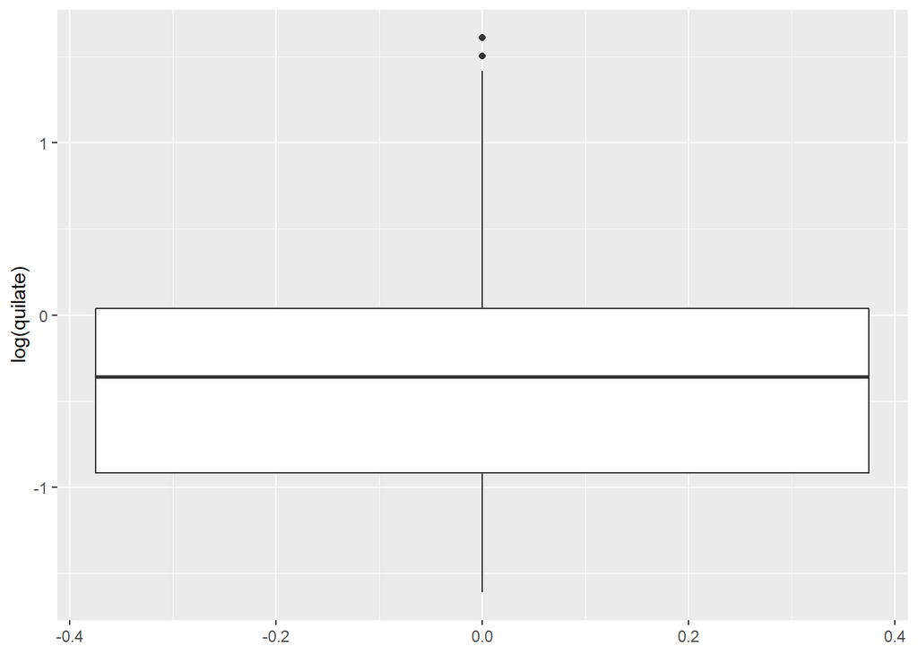

```r
ggplot(data = diamantes) +
  geom_boxplot(aes(y = log(quilate)))
```

A modo de gentil recordatorio, como vimos en la guía 1, un gráfico básico de boxplot es aún más rápido de escribir: `boxplot(log(diamantes$quilate))`

## 1.5 Sabe cómo importar una hoja de Excel en R?

Sí, si sabe: :-), ya lo ha hecho. Para más detalles, consulte el help de read_excel, del paquete readxl

```r
notas_curso_tbl <- read_excel("notas_curso.xlsx")
```

## 1.6 Ha escrito un `for` loop?

Bueno esto es un clásico de los lenguajes de programación. A veces se abusa de ellos, cuando existen alternativas que son más fáciles de leer. Pero otras los for loop presentan las cosas muy claramente y son muy muy flexibles.

Vamos a mostrar primero de forma muy sencilla como va cambiando el índice dento de del for loop y luego un ejemplo de como podemos ir guardando en un vector lo que calculamos en cada iteración.

Note que `{` y `}` marcan los límite del código (lo que calculamos) en un for loop

```r
# imprimir en la consola el valor de la variable-indice "i" en cada iteración

# recuerde que 1:4 es lo mismo que c(1, 2, 3, 4)
for (i in 1:4) {
  print(i)
}
```

```
## [1] 1
## [1] 2
## [1] 3
## [1] 4
```

```r
# la variable-indice puede tener cualquier nombre y puede usarse en los cálculos. De todas formas, las letras i,j,k son las usadas.
for (j in 1:5) {
  j_cuadrado <- j * j
  print(j_cuadrado)
}
```

```
## [1] 1
## [1] 4
## [1] 9
## [1] 16
## [1] 25
```

```r
# podemos usar el indice para ir asignando valores a los componentes de un vector, para poder guardar resultados

# primero, el vector donde guardaremos numeros
vector_con_resultados <- vector(length = 6)

for (i in 1:6) {
  resultado <- 1/i

  vector_con_resultados[i] <- resultado
}

print(resultado)
```

```
## [1] 0.1666667
```

### 1.6.1 Ejercicio

- Repita el segundo for loop, pero ahora debe calcular los cuadrados desde 1 a 8.
- Repita el tercer for loop, pero ahora el vector debe tener 10 elementos (es decir su largo es 10) y el índice del loop debe ir de 1 a 10.

## 1.7 Ha escrito una función?

Es muy sencillo (y además rápido si usan el autocompletar en RStudio después de escribir `fun`).

Primero escribamos una función muy sencilla para ver como funciona. Así como escribir for loops es una buena idea aprovechar el autocompletar de RStudio, también podemos usar el snippet de las funciones, escribiendo `fun` y apretando Tab y nos escribe el esqueleto de una función

```r
# esta función devuelve la suma de los números

mi_suma <- function(primer_numero, segundo_numero) {
  resultado <- primer_numero + segundo_numero
}

# ahora, que ya está definida, pruébela
mi_suma(3, 4)
mi_suma(9, 41)
mi_suma(50, 50)
```

Por defecto, la función entrega al usuario el ultimo objeto que calcula.

### 1.7.1 Ejercicio

- Cambie la función anterior, de modo que acepte tres argumentos en vez de dos y que el resultado de la función sea la suma de los tres argumentos
- Escriba una función que tome dos argumentos y cuyo resultado sea la multiplicación de los dos argumentos (es casi idéntica a `mi_suma`). Como nombre de la función, use `mi_multiplicacion`

## 1.8 Probabilidades discretas

```r
# numero de personas en la sala
n <- 50

# dia del año en que están de cumpleaños
# la función clave es sample. Note que estamos sampleando con reemplazo
# eso permite que si el día 113 ya salió, pueda salir otra vez
cumples <- sample(1:365, n, replace = TRUE)

# observe el resultado de esto
duplicated(c(1,2,3,1,4,3,5))
```

```
## [1] FALSE FALSE FALSE  TRUE FALSE  TRUE FALSE
```

```r
# any retorna TRUE si al menos
any(duplicated(cumples))
```

```
## [1] TRUE
```

```r
# para un grupo al azar de n personas
mismo_cumple <- function(n){
  cumples <- sample(1:365, n, replace=TRUE)
  any(duplicated(cumples))
}

# pruebe la nueva función:
mismo_cumple(20)
```

```
## [1] FALSE
```

```r
mismo_cumple(20)
```

```
## [1] FALSE
```

```r
mismo_cumple(20)
```

```
## [1] FALSE
```

```r
mismo_cumple(50)
```

```
## [1] TRUE
```

```r
# Replicate es muy similar a un for loop, pero escrito en forma
# más abreviada
B <- 10000
results <- replicate(B, mismo_cumple(50))

# recuerde que FALSE es tratado como 0 y TRUE como 1
mean(results)
```

```
## [1] 0.9701
```

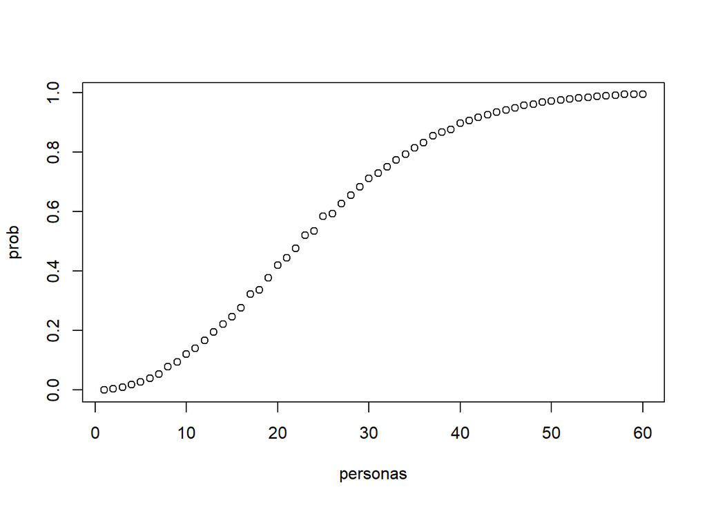

```r
# si quisieramos estimar la probabilidad con n=35 escribiriamos
results <- replicate(B, mismo_cumple(35))

# podemos escribir una función que nos permita variar el numero de repeticiones (B) y, mas importante, el número de personas en la sala (n)
compute_prob <- function(n, B=10000){
  results <- replicate(B, mismo_cumple(n))
  mean(results)
}

personas <- 1:60

# sapply es otra de las formas abreviadas de hacer lo mismo que un for loop
# el primer argumento es algo como 1:5 y el segundo es una función de la variable-índice del loop (i.e. de i=1,2,3 ...)

# En este caso calculara compute_prob(i), donde i va a ir tomando
# todos los valores en el vector personas (1,2,3 .... 60)
prob <- sapply(personas, compute_prob)

# mire como cambia la probabilidad de coincidencia
plot(personas, prob)
```

### 1.8.1 Ejercicio

- Para qué cantidades de personas las probabilidades de una coincidencia son mayores a 25%, 50% y 66,67%?
- Modifique el código para poder calcular la probabilidad de que al menos 3 personas tengan el mismo cumpleaños.